# Trabajo 1 (paso previo)

Cargar una base de datos de tiempo al evento a cometer un delito que deriva en sentencia definitiva condenatoria, pero condicional al policonsumo a la base (a la admisión).

Author

Andrés González Santa Cruz

Published

June 4, 2023

```r
rm(list = ls())
unlink("Trabahjo-1_files", recursive=T)
unlink("Trabahjo 1_files", recursive=T)
#fuentes:
#https://rpubs.com/georgy_makarov/897844
path<-paste0(getwd(),'/env')

#Sys.setenv(RETICULATE_PYTHON =  "")

#Sys.setenv(RETICULATE_PYTHON =  Sys.which("python"))

#reticulate::py_config()
#use_python(paste0(path,"/Scripts/python.exe"))

#Sys.setenv(LD_LIBRARY_PATH =  paste0(path,"/Lib"))
#Sys.setenv(LD_LIBRARY_PATH_64 =  paste0(path,"/Lib"))
#instalar paquetes de funcionalidades básicas para tener ubicaciones relativas y acceso a python (reticulate)
if(!require(reticulate)){install.packages("reticulate")}
if(!require(rstudioapi)){install.packages("rstudioapi")}
invisible("Create env")
#https://stackoverflow.com/questions/54043607/how-to-set-pyenv-python-for-reticulate
#Directory H:/Mi unidad/PERSONAL ANDRES/UCH_salud_publica/asignaturas/env is not a Python virtualenv
#virtualenv_create(envname  = path, packages = c("pip", "statsmodels", "matplotlib", "numpy", "pandas", "scipy"))
# "C:/Users/andre/anaconda3/python.exe" -m venv "H:/Mi unidad/PERSONAL ANDRES/UCH_salud_publica/asignaturas/9_Computacion_Estadistica/env"

#FUENTES:
#https://rstudio.github.io/reticulate/articles/versions.html
#Virtual environment functions are not supported on Windows (the use of conda environments is recommended on Windows).

invisible("Use environment")
#https://ugoproto.github.io/ugo_r_doc/pdf/reticulate.pdf


# tx  <- readLines(paste0(path,"/pyvenv.cfg"))
# tx[[1]] <- paste0("home = ",gsub('/', '\\', paste0(path,"/Scripts/python.exe"), fixed=T))
# tx[[3]] <- "version = 3.8.0"

#writeLines(tx, con=paste0(path,"/pyvenv.cfg"))

#H:/Mi unidad/PERSONAL ANDRES/UCH_salud_publica/asignaturas/env/Scripts/python.exe"
#use_virtualenv(path)

#usar entorno virtual ya creado
#información sobre entorno virtual
#py_discover_config()
#conda_python(envname =  "r-scrublet")


# FUENTES
#https://akrabat.com/creating-virtual-environments-with-pyenv/
#https://rstudio.github.io/reticulate/reference/install_python.html
#https://github.com/pyenv/pyenv/wiki#suggested-build-environment
#https://github.com/pyenv/pyenv
#https://stackoverflow.com/questions/56755156/reticulate-not-setting-python-path
#https://github.com/rstudio/reticulate/issues/291#issuecomment-437143751
#https://github.com/pyenv/pyenv
#https://github.com/pyenv-win/pyenv-win#installation
#https://stackoverflow.com/questions/52060867/how-to-use-pip-for-pyenv
#https://github.com/pyenv/pyenv/issues/2417
```

```python
!pyenv install -l | findstr 3.8
!pip install --upgrade pyenv-win
!env PYTHON_CONFIGURE_OPTS="--enable-shared" pyenv install
!env PYTHON_CONFIGURE_OPTS="--enable-shared" pyenv install 3.7.5
!pyenv build
```

# Carga de datos y exploración

## Cargar paquetes

Cargar paquetes

```r
tryCatch(
  base_senda_fiscalia<<- rio::import("C:/Users/CISS Fondecyt/Mi unidad/Alvacast/SISTRAT 2022 (github)/fiscalia_mariel_feb_2023_match_SENDA_miss.dta"),
  error= function(e){
    base_senda_fiscalia<<-rio::import("E:/Mi unidad/Alvacast/SISTRAT 2022 (github)/fiscalia_mariel_feb_2023_match_SENDA_miss.dta")
  }
)
paste0("Base de datos original: ", format(nrow(base_senda_fiscalia),big.mark="."), " pacientes")
```

```
[1] "Base de datos original: 70.863 pacientes"
```

Esta base de datos está compuesta por registros de sujetos del SENDA del 2010 al 2019, más registros de delitos imputados a estas personas (si los hay) en el mismo periodo mediante solicitud a Fiscalía. La fecha de obtención de la base de datos (censura a la derecha) fue definida como el 13 de Noviembre de 2019. Se considera el primer tratamiento registrado por cada paciente en las fechas de seguimiento (2010-2019). Las variables a estudiar son las siguientes:

- HASH (RUT encriptado en formato MD5 más un Salt-Key) `hash_key`
- **Exposición**: Trastornos por consumo de sustancias concurrentes (consumo de varias sustancias) (**PSU**) al momento de ser admitido `policonsumo`
- **Resultado**: Motivo de egreso (completar=1; abandono temprano o <90=2; abandono tardío o >=90 días=3) `motivodeegreso_mod_imp_rec` . Consideraremos un evento el completar el tratamiento.
  - El tiempo-al-resultado se generará mediante la resta entre la edad al egreso `edad_al_egres_imp` y la edad al ingreso a tratamiento `edad_al_ing_1` , de producirse el evento. En caso contrario, se ingresará la edad al tiempo de censura.
- Alternativamente, se estudiará la relación entre policonsumo y la comisión de un delito en calidad imputado por el que recibe sentencia definitiva condenatoria después de haber ingresado a tratamiento `offender_d` (1= “SI”). Consideraremos un evento el cometer un delito.
  - El tiempo al evento se generará mediante la resta entre la edad al cometer el delito (`age_offending_imp`) edad al ingreso a tratamiento `edad_al_ing_1`, de producirse el evento. En caso contrario, se ingresará la edad al tiempo de censura.
- El tiempo al la fecha de censura se construirá con la edad al momento de censura administrativa `age_at_censor_date`

```r
base_senda_fiscalia<-
base_senda_fiscalia %>% dplyr::mutate(time= edad_al_egres_imp-edad_al_ing_1 ) %>%  dplyr::filter(time>0) %>% dplyr::select(-time)
```

```r
#rcs(edad_al_ing_1, 4) + sex + edad_ini_cons + escolaridad_rec + condicion_ocupacional_corr + num_hijos_mod_joel_bin + tenencia_de_la_vivienda_mod + macrozona + n_off_vio + n_off_acq + n_off_sud + n_off_oth + dg_cie_10_rec + dg_trs_cons_sus_or + clas_r + porc_pobr + sus_ini_mod_mvv + ano_nac_corr + con_quien_vive_joel + fis_comorbidity_icd_10

#etiquetamos las variables:
attr(base_senda_fiscalia$hash_key, "label") <- "HASH (RUT encriptado en formato MD5 más un Salt-Key)"
attr(base_senda_fiscalia$policonsumo, "label") <- "Trastornos por consumo de sustancias concurrentes (consumo de varias sustancias)"
attr(base_senda_fiscalia$edad_al_ing_1, "label") <- "Edad (ingreso al tratamiento)"
attr(base_senda_fiscalia$motivodeegreso_mod_imp_rec, "label") <- "Motivo de egreso (1= Completar; 2= Abandono temprano; 3= Abandono tardío)"
attr(base_senda_fiscalia$edad_al_egres_imp, "label") <- "Edad al egreso de tratamiento"
attr(base_senda_fiscalia$offender_d , "label") <- "Delito cometido (Perdido= no registra delito)"
attr(base_senda_fiscalia$age_offending_imp, "label") <- "Edad de comisión de delito"
attr(base_senda_fiscalia$sex, "label") <- "Sexo"
attr(base_senda_fiscalia$edad_ini_cons, "label") <- "Edad de inicio del consumo de sustancias"
attr(base_senda_fiscalia$escolaridad_rec, "label") <- "Nivel educativo"
attr(base_senda_fiscalia$condicion_ocupacional_corr, "label") <- "Condición ocupacional corregida"
attr(base_senda_fiscalia$num_hijos_mod_joel_bin, "label") <- "Número de hijos (dicotomizado)"
attr(base_senda_fiscalia$tenencia_de_la_vivienda_mod, "label") <- "Situación de vivienda (estatus de tenencia)"
attr(base_senda_fiscalia$macrozona, "label") <- "Macrozona administrativa en Chile"
attr(base_senda_fiscalia$n_off_vio, "label") <- "Delitos violentos (previos al tratamiento)"
attr(base_senda_fiscalia$n_off_acq, "label") <- "Delitos de adquisición (previos al tratamiento)"
attr(base_senda_fiscalia$n_off_sud, "label") <- "Delitos relacionados con sustancias (previos al tratamiento)"
attr(base_senda_fiscalia$n_off_oth, "label") <- "Otros delitos (previos al tratamiento)"
attr(base_senda_fiscalia$dg_cie_10_rec, "label") <- "Comorbilidad psiquiátrica (CIE-10) (1= Nada)"
attr(base_senda_fiscalia$dg_trs_cons_sus_or, "label") <- "Gravedad del trastorno por consumo de sustancias (estatus de dependencia)"
attr(base_senda_fiscalia$clas_r, "label") <- "Clasificación socioeconómica"
attr(base_senda_fiscalia$porc_pobr, "label") <- "Porcentaje de personas en pobreza"
attr(base_senda_fiscalia$sus_ini_mod_mvv, "label") <- "Sustancia principal (diagnóstico inicial)"
attr(base_senda_fiscalia$ano_nac_corr, "label") <- "Año de nacimiento corregido"
attr(base_senda_fiscalia$con_quien_vive_joel, "label") <- "Estado de convivencia (recodificado) (Con pareja/hijos, Con familia de origen, Solo, Otros)"
attr(base_senda_fiscalia$fis_comorbidity_icd_10, "label") <- "Comorbilidad física (CIE-10)"
```

# Balance

(*) En un estudio previo con los mismos datos, el modelo que encontró mejor ajuste a los datos sin violar el supuesto de linealidad de la variables llevó a cabo dicha transformación. Dado que el objetivo de estudio está puesto en el policonsumo y su impacto sobre completar el tratamiento, se sacrificó interpretabilidad de la variable por el ajuste del modelo.

Exploramos los datos:

```r
#controlly
# Treatment status (Early dropout/Late dropout/Treatment completion)

as.data.frame.TableOne <- function(x, ...) {capture.output(print(x,
                          showAllLevels = TRUE, ...) -> x)
  y <- as.data.frame(x)
  y$characteristic <- dplyr::na_if(rownames(x), "")
  y <- y %>%
  fill(characteristic, .direction = "down") %>%
  select(characteristic, everything())
  rownames(y) <- NULL
  y}


#to format rows in bold
format_cells <- function(df, rows ,cols, value = c("italics", "bold", "strikethrough")){

  # select the correct markup
  # one * for italics, two ** for bold
  map <- setNames(c("*", "**", "~~"), c("italics", "bold", "strikethrough"))
  markup <- map[value]

  for (r in rows){
    for(c in cols){

      # Make sure values are not factors
      df[[c]] <- as.character( df[[c]])

      # Update formatting
      df[r, c] <- ifelse(nchar(df[r, c])==0,"",paste0(markup, gsub(" ", "", df[r, c]), markup))
    }
  }

  return(df)
}

#_#_#_#_#_#_#_#_#_#_#_#_#_#_#_#_#_#_#_#_#_#_#_#_#_#_#_#_#_#_#_#_
vars_cov<-c("motivodeegreso_mod_imp_rec",  "edad_al_ing_1", "sex", "edad_ini_cons", "escolaridad_rec", "condicion_ocupacional_corr",  "num_hijos_mod_joel_bin", "tenencia_de_la_vivienda_mod", "macrozona", "n_off_vio", "n_off_acq",  "n_off_sud", "n_off_oth", "dg_cie_10_rec", "dg_trs_cons_sus_or", "clas_r", "porc_pobr", "sus_ini_mod_mvv", "ano_nac_corr", "con_quien_vive_joel", "fis_comorbidity_icd_10")
#_#_#_#_#_#_#_#_#_#_#_#_#_#_#_#_#_#_#_#_#_#_#_#_#_#_#_#_#_#_#_#_

#to format rows in bold
format_cells <- function(df, rows ,cols, value = c("italics", "bold", "strikethrough")){

  # select the correct markup
  # one * for italics, two ** for bold
  map <- setNames(c("*", "**", "~~"), c("italics", "bold", "strikethrough"))
  markup <- map[value]

  for (r in rows){
    for(c in cols){

      # Make sure values are not factors
      df[[c]] <- as.character( df[[c]])

      # Update formatting
      df[r, c] <- ifelse(nchar(df[r, c])==0,"",paste0(markup, gsub(" ", "", df[r, c]), markup))
    }
  }

  return(df)
}
#_#_#_#_#_#_#_#_#_#_#_#_#_#_#_#_#_#_#_#_#_#_#_#_#_#_#_#_#_#_#_#_
#_#_#_#_#_#_#_#_#_#_#_#_#_#_#_#_#_#_#_#_#_#_#_#_#_#_#_#_#_#_#_#_

tbone_desc<-
CreateTableOne(vars=c(vars_cov), data=  base_senda_fiscalia %>% dplyr::mutate(
    sex = case_when(
      sex == "1" ~ "Male",
      sex == "2" ~ "Female",
      TRUE ~ "Unknown"
    ),
    escolaridad_rec = case_when(
      escolaridad_rec == 3 ~ "Primaria o menos",
      escolaridad_rec == 2 ~ "Secundaria o menos",
      escolaridad_rec == 1 ~ "Más que secundaria",
      TRUE ~ "Unknown"
    ),
    condicion_ocupacional_corr = case_when(
      condicion_ocupacional_corr == 1 ~ "Empleado",
      condicion_ocupacional_corr == 2 ~ "Inactivo",
      condicion_ocupacional_corr == 3 ~ "Buscando por primera vez",
      condicion_ocupacional_corr == 4 ~ "Sin actividad",
      condicion_ocupacional_corr == 5 ~ "No busca",
      condicion_ocupacional_corr == 6 ~ "Desempleado",
      TRUE ~ "Unknown"
    ),
    num_hijos_mod_joel_bin = recode(num_hijos_mod_joel_bin, "1" = "Uno o más hijos", "0"= "Sin hijos"),
    tenencia_de_la_vivienda_mod = recode(tenencia_de_la_vivienda_mod,
                                          "1" = "Asentamiento ilegal",
                                          "2" = "Otro",
                                          "3" = "Propietario/dividendo",
                                          "4" = "Arrendando",
                                          "5" = "Allegado"),
    macrozona = recode(macrozona, "1" = "Centro", "2" = "Norte", "3" = "Sur"),
    n_off_vio = recode(n_off_vio, "2" = "Uno o más delitos violentos", "1"= "Sin registro" ),
    n_off_acq = recode(n_off_acq, "2" = "Uno o más delitos adquisitivos", "1"= "Sin registro"),
    n_off_sud = recode(n_off_sud, "2" = "Uno o más delitos ligados a sustanicas", "1"= "Sin registro"),
    n_off_oth = recode(n_off_oth, "2" = "Uno o más delitos (otros)", "1"= "Sin registro"),
    dg_cie_10_rec = recode(dg_cie_10_rec,
                           "1" = "Sin comorbilidad",
                           "2" = "En estudio",
                           "3" = "Comorbilidad"),
    clas_r = recode(clas_r,
                    "1" = "Urbano",
                    "2" = "Mixto",
                    "3" = "Rural"),
        clas_r = recode(sus_ini_mod_mvv,
                    "Cocaine hydrochloride" = "Cocaína",
                    "Cocaine paste" = "Pasta base",
                    "Marijuana" = "Marihuana",
                    "Other" = "Otro"),
     con_quien_vive_joel = recode(con_quien_vive_joel, "With couple/children"= "Con pareja/hijos", "With family of origin"= "Con familia de orígen", "Alone" = "Solo", "Others"= "Otros"),
    fis_comorbidity_icd_10 = recode(fis_comorbidity_icd_10,
                           "1" = "Sin comorbilidad",
                           "2" = "En estudio",
                           "3" = "Comorbilidad"),
    # Add here more variables using the same pattern...
  ), factorVars = setdiff(vars_cov, c("motivodeegreso_mod_imp_rec","edad_al_ing_1", "edad_ini_cons","ano_nac_corr", "porc_pobr")), smd=F, strata="policonsumo", addOverall = T, includeNA=T, test=F)

#_#_#_#_#_#_#_#_#_#_#_#_#_#_#_#_#_#_#_#_#_#_#_#_#_#_#_#_#_#_#_#_
#_#_#_#_#_#_#_#_#_#_#_#_#_#_#_#_#_#_#_#_#_#_#_#_#_#_#_#_#_#_#_#_

as.data.frame.TableOne(tbone_desc, smd=F, nonnormal= T)%>%
  dplyr::mutate(char2=characteristic) %>%
  tidyr::fill(char2) %>%
  dplyr::select(char2,everything()) %>%
  dplyr::mutate(level=ifelse(is.na(level),"[Missing]",level)) %>%
  dplyr::mutate(char2=dplyr::case_when(characteristic=="NA"~NA_character_,T~as.character(characteristic))) %>%
  format_cells(1, 1:length(names(.)), "bold") %>%
  dplyr::select(-1) %>%
  knitr::kable(size=10, format="markdown",caption= "Resumen descriptivos, según  PSU(0) y PSU (1)", escape=T)
```

```
fill: changed 34 values (61%) of 'characteristic' (34 fewer NA)
```

```
select: columns reordered (characteristic, level, Overall, 0, 1)
```

Resumen descriptivos, según PSU(0) y PSU (1)

| characteristic | level | Overall | 0 | 1 |
| --- | --- | --- | --- | --- |
| **n** |  | **70788** | **18425** | **52363** |
| motivodeegreso_mod_imp_rec (median [IQR]) |  | 3.00 [1.00, 3.00] | 2.00 [1.00, 3.00] | 3.00 [2.00, 3.00] |
| edad_al_ing_1 (median [IQR]) |  | 34.06 [27.39, 42.91] | 41.48 [32.18, 50.99] | 32.28 [26.48, 39.76] |
| sex (%) | Unknown | 70788 (100.0) | 18425 (100.0) | 52363 (100.0) |
| edad_ini_cons (median [IQR]) |  | 15.00 [14.00, 18.00] | 17.00 [14.00, 20.00] | 15.00 [13.00, 17.00] |
| escolaridad_rec (%) | Más que secundaria | 20309 ( 28.7) | 6733 ( 36.5) | 13576 ( 25.9) |
| escolaridad_rec (%) | Primaria o menos | 11340 ( 16.0) | 2496 ( 13.5) | 8844 ( 16.9) |
| escolaridad_rec (%) | Secundaria o menos | 39139 ( 55.3) | 9196 ( 49.9) | 29943 ( 57.2) |
| condicion_ocupacional_corr (%) | Buscando por primera vez | 159 ( 0.2) | 28 ( 0.2) | 131 ( 0.3) |
| condicion_ocupacional_corr (%) | Desempleado | 23881 ( 33.7) | 4511 ( 24.5) | 19370 ( 37.0) |
| condicion_ocupacional_corr (%) | Empleado | 35333 ( 49.9) | 10595 ( 57.5) | 24738 ( 47.2) |
| condicion_ocupacional_corr (%) | Inactivo | 7162 ( 10.1) | 2410 ( 13.1) | 4752 ( 9.1) |
| condicion_ocupacional_corr (%) | No busca | 712 ( 1.0) | 122 ( 0.7) | 590 ( 1.1) |
| condicion_ocupacional_corr (%) | Sin actividad | 3541 ( 5.0) | 759 ( 4.1) | 2782 ( 5.3) |
| num_hijos_mod_joel_bin (%) | Sin hijos | 16511 ( 23.3) | 3325 ( 18.0) | 13186 ( 25.2) |
| num_hijos_mod_joel_bin (%) | Uno o más hijos | 54277 ( 76.7) | 15100 ( 82.0) | 39177 ( 74.8) |
| tenencia_de_la_vivienda_mod (%) | Allegado | 27871 ( 39.4) | 5699 ( 30.9) | 22172 ( 42.3) |
| tenencia_de_la_vivienda_mod (%) | Arrendando | 13626 ( 19.2) | 3500 ( 19.0) | 10126 ( 19.3) |
| tenencia_de_la_vivienda_mod (%) | Asentamiento ilegal | 775 ( 1.1) | 177 ( 1.0) | 598 ( 1.1) |
| tenencia_de_la_vivienda_mod (%) | Otro | 2029 ( 2.9) | 522 ( 2.8) | 1507 ( 2.9) |
| tenencia_de_la_vivienda_mod (%) | Propietario/dividendo | 26487 ( 37.4) | 8527 ( 46.3) | 17960 ( 34.3) |
| macrozona (%) | Centro | 53628 ( 75.8) | 13782 ( 74.8) | 39846 ( 76.1) |
| macrozona (%) | Norte | 10483 ( 14.8) | 1852 ( 10.1) | 8631 ( 16.5) |
| macrozona (%) | Sur | 6677 ( 9.4) | 2791 ( 15.1) | 3886 ( 7.4) |
| n_off_vio (%) | Sin registro | 58885 ( 83.2) | 15428 ( 83.7) | 43457 ( 83.0) |
| n_off_vio (%) | Uno o más delitos violentos | 11903 ( 16.8) | 2997 ( 16.3) | 8906 ( 17.0) |
| n_off_acq (%) | Sin registro | 58022 ( 82.0) | 16170 ( 87.8) | 41852 ( 79.9) |
| n_off_acq (%) | Uno o más delitos adquisitivos | 12766 ( 18.0) | 2255 ( 12.2) | 10511 ( 20.1) |
| n_off_sud (%) | Sin registro | 58364 ( 82.4) | 15881 ( 86.2) | 42483 ( 81.1) |
| n_off_sud (%) | Uno o más delitos ligados a sustanicas | 12424 ( 17.6) | 2544 ( 13.8) | 9880 ( 18.9) |
| n_off_oth (%) | Sin registro | 58537 ( 82.7) | 15595 ( 84.6) | 42942 ( 82.0) |
| n_off_oth (%) | Uno o más delitos (otros) | 12251 ( 17.3) | 2830 ( 15.4) | 9421 ( 18.0) |
| dg_cie_10_rec (%) | Comorbilidad | 29636 ( 41.9) | 7114 ( 38.6) | 22522 ( 43.0) |
| dg_cie_10_rec (%) | En estudio | 13239 ( 18.7) | 2844 ( 15.4) | 10395 ( 19.9) |
| dg_cie_10_rec (%) | Sin comorbilidad | 27913 ( 39.4) | 8467 ( 46.0) | 19446 ( 37.1) |
| dg_trs_cons_sus_or (%) | Drug dependence | 51103 ( 72.2) | 11291 ( 61.3) | 39812 ( 76.0) |
| dg_trs_cons_sus_or (%) | Hazardous consumption | 19685 ( 27.8) | 7134 ( 38.7) | 12551 ( 24.0) |
| clas_r (%) | Alcohol | 42170 ( 59.6) | 13212 ( 71.7) | 28958 ( 55.3) |
| clas_r (%) | Cocaína | 4010 ( 5.7) | 936 ( 5.1) | 3074 ( 5.9) |
| clas_r (%) | Marihuana | 19647 ( 27.8) | 2654 ( 14.4) | 16993 ( 32.5) |
| clas_r (%) | Otro | 1650 ( 2.3) | 493 ( 2.7) | 1157 ( 2.2) |
| clas_r (%) | Pasta base | 3311 ( 4.7) | 1130 ( 6.1) | 2181 ( 4.2) |
| porc_pobr (median [IQR]) |  | 0.12 [0.07, 0.17] | 0.11 [0.07, 0.16] | 0.12 [0.08, 0.17] |
| sus_ini_mod_mvv (%) | Alcohol | 42170 ( 59.6) | 13212 ( 71.7) | 28958 ( 55.3) |
| sus_ini_mod_mvv (%) | Cocaine hydrochloride | 4010 ( 5.7) | 936 ( 5.1) | 3074 ( 5.9) |
| sus_ini_mod_mvv (%) | Cocaine paste | 3311 ( 4.7) | 1130 ( 6.1) | 2181 ( 4.2) |
| sus_ini_mod_mvv (%) | Marijuana | 19647 ( 27.8) | 2654 ( 14.4) | 16993 ( 32.5) |
| sus_ini_mod_mvv (%) | Other | 1650 ( 2.3) | 493 ( 2.7) | 1157 ( 2.2) |
| ano_nac_corr (median [IQR]) |  | 1980.00 [1971.00, 1987.00] | 1973.00 [1964.00, 1983.00] | 1981.00 [1974.00, 1988.00] |
| con_quien_vive_joel (%) | Con pareja/hijos | 28698 ( 40.5) | 9134 ( 49.6) | 19564 ( 37.4) |
| con_quien_vive_joel (%) | Family of origin | 29298 ( 41.4) | 5540 ( 30.1) | 23758 ( 45.4) |
| con_quien_vive_joel (%) | Otros | 6104 ( 8.6) | 1497 ( 8.1) | 4607 ( 8.8) |
| con_quien_vive_joel (%) | Solo | 6688 ( 9.4) | 2254 ( 12.2) | 4434 ( 8.5) |
| fis_comorbidity_icd_10 (%) | Comorbilidad | 4412 ( 6.2) | 1368 ( 7.4) | 3044 ( 5.8) |
| fis_comorbidity_icd_10 (%) | En estudio | 38379 ( 54.2) | 10211 ( 55.4) | 28168 ( 53.8) |
| fis_comorbidity_icd_10 (%) | Sin comorbilidad | 27997 ( 39.6) | 6846 ( 37.2) | 21151 ( 40.4) |

```r
#kable(size=10, format="html",caption= "Resumen descriptivos, según  PSU(0) y PSU (1)") %>%     kableExtra::kable_classic()
```

## Generar una submuestra

```r
set.seed(2125)
m.out <- MatchIt::matchit(policonsumo ~ rcs(edad_al_ing_1, 4) + sex + edad_ini_cons + escolaridad_rec + condicion_ocupacional_corr + num_hijos_mod_joel_bin + tenencia_de_la_vivienda_mod + macrozona + n_off_vio + n_off_acq + n_off_sud + n_off_oth + dg_cie_10_rec + dg_trs_cons_sus_or + clas_r + porc_pobr + sus_ini_mod_mvv + ano_nac_corr + con_quien_vive_joel + fis_comorbidity_icd_10,
  data = base_senda_fiscalia, method = "quick", discard="none", time=60*60, caliper=.1, estimand="ATE", subclass = 10) #="gurobi", )#replace = TRUE,
m.out
```

```
A matchit object
 - method: Generalized full matching
 - distance: Propensity score [caliper]
             - estimated with logistic regression
 - caliper: <distance> (0.02)
 - number of obs.: 70788 (original), 70788 (matched)
 - target estimand: ATE
 - covariates: rcs(edad_al_ing_1, 4), sex, edad_ini_cons, escolaridad_rec, condicion_ocupacional_corr, num_hijos_mod_joel_bin, tenencia_de_la_vivienda_mod, macrozona, n_off_vio, n_off_acq, n_off_sud, n_off_oth, dg_cie_10_rec, dg_trs_cons_sus_or, clas_r, porc_pobr, sus_ini_mod_mvv, ano_nac_corr, con_…
```

```r
m.out2 <- matchit(policonsumo ~ rcs(edad_al_ing_1, 4) + sex + edad_ini_cons + escolaridad_rec + condicion_ocupacional_corr + num_hijos_mod_joel_bin + tenencia_de_la_vivienda_mod + macrozona + n_off_vio + n_off_acq + n_off_sud + n_off_oth + dg_cie_10_rec + dg_trs_cons_sus_or + clas_r + porc_pobr + sus_ini_mod_mvv + ano_nac_corr + con_quien_vive_joel + fis_comorbidity_icd_10,
                  data = base_senda_fiscalia,
                  method = "nearest",
                  discard = "both")
m.out2
```

```
A matchit object
 - method: 1:1 nearest neighbor matching without replacement
 - distance: Propensity score [common support]
             - estimated with logistic regression
 - common support: units from both groups dropped
 - number of obs.: 70788 (original), 36842 (matched)
 - target estimand: ATT
 - covariates: rcs(edad_al_ing_1, 4), sex, edad_ini_cons, escolaridad_rec, condicion_ocupacional_corr, num_hijos_mod_joel_bin, tenencia_de_la_vivienda_mod, macrozona, n_off_vio, n_off_acq, n_off_sud, n_off_oth, dg_cie_10_rec, dg_trs_cons_sus_or, clas_r, porc_pobr, sus_ini_mod_mvv, ano_nac_corr, con_…
```

```r
m.out3 <- matchit(policonsumo ~ rcs(edad_al_ing_1, 4) + sex + edad_ini_cons + escolaridad_rec + condicion_ocupacional_corr + num_hijos_mod_joel_bin + tenencia_de_la_vivienda_mod + macrozona + n_off_vio + n_off_acq + n_off_sud + n_off_oth + dg_cie_10_rec + dg_trs_cons_sus_or + clas_r + porc_pobr + sus_ini_mod_mvv + ano_nac_corr + con_quien_vive_joel + fis_comorbidity_icd_10,
                  data = base_senda_fiscalia,
                  method = "nearest",
                  discard = "both",
                  caliper = .01,
                  standardize = T)
m.out3
```

```
A matchit object
 - method: 1:1 nearest neighbor matching without replacement
 - distance: Propensity score [caliper, common support]
             - estimated with logistic regression
 - caliper: <distance> (0.002)
 - common support: units from both groups dropped
 - number of obs.: 70788 (original), 29742 (matched)
 - target estimand: ATT
 - covariates: rcs(edad_al_ing_1, 4), sex, edad_ini_cons, escolaridad_rec, condicion_ocupacional_corr, num_hijos_mod_joel_bin, tenencia_de_la_vivienda_mod, macrozona, n_off_vio, n_off_acq, n_off_sud, n_off_oth, dg_cie_10_rec, dg_trs_cons_sus_or, clas_r, porc_pobr, sus_ini_mod_mvv, ano_nac_corr, con_…
```

Comparamos el balance logrado por cada uno de los modelos

```r
cobalt::bal.tab(m.out, un = TRUE, m.threshold = .1,
        v.threshold = 2)
```

```
Balance Measures
                                             Type Diff.Un V.Ratio.Un Diff.Adj
distance                                 Distance  1.0514     0.4007   0.0000
edad_al_ing_1                             Contin. -0.7387     0.5723   0.0167
edad_al_ing_1'                            Contin. -0.7142     0.2958   0.0163
edad_al_ing_1''                           Contin. -0.6808     0.2436   0.0152
sex_Women                                  Binary -0.0225          .  -0.0065
edad_ini_cons                             Contin. -0.4109     0.4104  -0.0040
escolaridad_rec                           Contin.  0.2119     0.9374  -0.0021
condicion_ocupacional_corr                Contin.  0.2892     1.2074   0.0021
num_hijos_mod_joel_bin                     Binary -0.0714          .  -0.0109
tenencia_de_la_vivienda_mod               Contin.  0.2336     1.0758   0.0183
macrozona                                 Contin. -0.1340     0.6687   0.0360
n_off_vio_2                                Binary  0.0074          .   0.0022
n_off_acq_2                                Binary  0.0783          .  -0.0046
n_off_sud_2                                Binary  0.0506          .  -0.0033
n_off_oth_2                                Binary  0.0263          .  -0.0038
dg_cie_10_rec                             Contin.  0.1460     0.9497   0.0136
dg_trs_cons_sus_or_Hazardous consumption   Binary -0.1475          .  -0.0159
clas_r                                    Contin. -0.2656     0.6073   0.0132
porc_pobr                                 Contin.  0.1027     1.0201   0.0161
sus_ini_mod_mvv_Alcohol                    Binary -0.1640          .   0.0210
sus_ini_mod_mvv_Cocaine hydrochloride      Binary  0.0079          .  -0.0037
sus_ini_mod_mvv_Cocaine paste              Binary -0.0197          .  -0.0050
sus_ini_mod_mvv_Marijuana                  Binary  0.1805          .  -0.0125
sus_ini_mod_mvv_Other                      Binary -0.0047          .   0.0002
ano_nac_corr                              Contin.  0.6268     0.6261  -0.0200
con_quien_vive_joel_Alone                  Binary -0.0377          .   0.0012
con_quien_vive_joel_Family of origin       Binary  0.1530          .   0.0055
con_quien_vive_joel_Others                 Binary  0.0067          .  -0.0019
con_quien_vive_joel_With couple/children   Binary -0.1221          .  -0.0048
fis_comorbidity_icd_10                    Contin. -0.0820     0.9582   0.0083
                                            M.Threshold V.Ratio.Adj
distance                                 Balanced, <0.1      0.9999
edad_al_ing_1                            Balanced, <0.1      1.0087
edad_al_ing_1'                           Balanced, <0.1      0.9973
edad_al_ing_1''                          Balanced, <0.1      0.9884
sex_Women                                Balanced, <0.1           .
edad_ini_cons                            Balanced, <0.1      1.4119
escolaridad_rec                          Balanced, <0.1      0.9834
```

[output cut: 63 more lines]

```

Balance tally for variance ratios
                 count
Balanced, <2        14
Not Balanced, >2     0

Variable with the greatest variance ratio
      Variable V.Ratio.Adj  V.Threshold
 edad_ini_cons      1.4119 Balanced, <2

Sample sizes
                      Control  Treated
All                  18425.   52363.
Matched (ESS)         8181.09 37891.93
Matched (Unweighted) 18425.   52363.
```

```r
cobalt::bal.tab(m.out2, un = TRUE, m.threshold = .1,
        v.threshold = 2)
```

```
Balance Measures
                                             Type Diff.Un V.Ratio.Un Diff.Adj
distance                                 Distance  1.3901     0.4007   2.2339
edad_al_ing_1                             Contin. -0.8657     0.5723  -1.3841
edad_al_ing_1'                            Contin. -1.0571     0.2958  -1.5075
edad_al_ing_1''                           Contin. -1.0876     0.2436  -1.4837
sex_Women                                  Binary -0.0225          .  -0.0501
edad_ini_cons                             Contin. -0.5386     0.4104  -0.8227
escolaridad_rec                           Contin.  0.2154     0.9374   0.3445
condicion_ocupacional_corr                Contin.  0.2765     1.2074   0.6121
num_hijos_mod_joel_bin                     Binary -0.0714          .  -0.1441
tenencia_de_la_vivienda_mod               Contin.  0.2294     1.0758   0.4001
macrozona                                 Contin. -0.1496     0.6687  -0.2472
n_off_vio_2                                Binary  0.0074          .  -0.0034
n_off_acq_2                                Binary  0.0783          .   0.1519
n_off_sud_2                                Binary  0.0506          .   0.0897
n_off_oth_2                                Binary  0.0263          .   0.0382
dg_cie_10_rec                             Contin.  0.1480     0.9497   0.3265
dg_trs_cons_sus_or_Hazardous consumption   Binary -0.1475          .  -0.3039
clas_r                                    Contin. -0.3056     0.6073  -0.5324
porc_pobr                                 Contin.  0.1021     1.0201   0.2867
sus_ini_mod_mvv_Alcohol                    Binary -0.1640          .  -0.3514
sus_ini_mod_mvv_Cocaine hydrochloride      Binary  0.0079          .   0.0056
sus_ini_mod_mvv_Cocaine paste              Binary -0.0197          .  -0.0521
sus_ini_mod_mvv_Marijuana                  Binary  0.1805          .   0.4073
sus_ini_mod_mvv_Other                      Binary -0.0047          .  -0.0093
ano_nac_corr                              Contin.  0.7143     0.6261   1.0623
con_quien_vive_joel_Alone                  Binary -0.0377          .  -0.0629
con_quien_vive_joel_Family of origin       Binary  0.1530          .   0.2977
con_quien_vive_joel_Others                 Binary  0.0067          .   0.0136
con_quien_vive_joel_With couple/children   Binary -0.1221          .  -0.2484
fis_comorbidity_icd_10                    Contin. -0.0828     0.9582  -0.1097
                                                M.Threshold V.Ratio.Adj
distance                                                         0.0110
edad_al_ing_1                            Not Balanced, >0.1      0.2306
edad_al_ing_1'                           Not Balanced, >0.1      0.0275
edad_al_ing_1''                          Not Balanced, >0.1      0.0111
sex_Women                                    Balanced, <0.1           .
edad_ini_cons                            Not Balanced, >0.1      0.1391
escolaridad_rec                          Not Balanced, >0.1      0.8775
```

[output cut: 64 more lines]

```
Balance tally for variance ratios
                 count
Balanced, <2         7
Not Balanced, >2     6

Variable with the greatest variance ratio
        Variable V.Ratio.Adj      V.Threshold
 edad_al_ing_1''      0.0111 Not Balanced, >2

Sample sizes
          Control Treated
All         18425   52363
Matched     18421   18421
Unmatched       0   33864
Discarded       4      78
```

```r
cobalt::bal.tab(m.out3, un = TRUE, m.threshold = .1,
        v.threshold = 2)
```

```
Balance Measures
                                             Type Diff.Un V.Ratio.Un Diff.Adj
distance                                 Distance  1.3901     0.4007   0.0105
edad_al_ing_1                             Contin. -0.8657     0.5723   0.0081
edad_al_ing_1'                            Contin. -1.0571     0.2958   0.0281
edad_al_ing_1''                           Contin. -1.0876     0.2436   0.0351
sex_Women                                  Binary -0.0225          .   0.0053
edad_ini_cons                             Contin. -0.5386     0.4104   0.0157
escolaridad_rec                           Contin.  0.2154     0.9374  -0.0053
condicion_ocupacional_corr                Contin.  0.2765     1.2074   0.0100
num_hijos_mod_joel_bin                     Binary -0.0714          .   0.0005
tenencia_de_la_vivienda_mod               Contin.  0.2294     1.0758  -0.0177
macrozona                                 Contin. -0.1496     0.6687  -0.0143
n_off_vio_2                                Binary  0.0074          .  -0.0030
n_off_acq_2                                Binary  0.0783          .   0.0020
n_off_sud_2                                Binary  0.0506          .   0.0016
n_off_oth_2                                Binary  0.0263          .  -0.0024
dg_cie_10_rec                             Contin.  0.1480     0.9497   0.0143
dg_trs_cons_sus_or_Hazardous consumption   Binary -0.1475          .   0.0014
clas_r                                    Contin. -0.3056     0.6073  -0.0157
porc_pobr                                 Contin.  0.1021     1.0201  -0.0014
sus_ini_mod_mvv_Alcohol                    Binary -0.1640          .  -0.0231
sus_ini_mod_mvv_Cocaine hydrochloride      Binary  0.0079          .   0.0045
sus_ini_mod_mvv_Cocaine paste              Binary -0.0197          .   0.0001
sus_ini_mod_mvv_Marijuana                  Binary  0.1805          .   0.0177
sus_ini_mod_mvv_Other                      Binary -0.0047          .   0.0008
ano_nac_corr                              Contin.  0.7143     0.6261  -0.0132
con_quien_vive_joel_Alone                  Binary -0.0377          .  -0.0011
con_quien_vive_joel_Family of origin       Binary  0.1530          .  -0.0010
con_quien_vive_joel_Others                 Binary  0.0067          .  -0.0016
con_quien_vive_joel_With couple/children   Binary -0.1221          .   0.0038
fis_comorbidity_icd_10                    Contin. -0.0828     0.9582   0.0056
                                            M.Threshold V.Ratio.Adj
distance                                 Balanced, <0.1      1.0063
edad_al_ing_1                            Balanced, <0.1      1.0363
edad_al_ing_1'                           Balanced, <0.1      1.0330
edad_al_ing_1''                          Balanced, <0.1      1.0295
sex_Women                                Balanced, <0.1           .
edad_ini_cons                            Balanced, <0.1      1.2886
escolaridad_rec                          Balanced, <0.1      0.9704
```

[output cut: 64 more lines]

```
Balance tally for variance ratios
                 count
Balanced, <2        14
Not Balanced, >2     0

Variable with the greatest variance ratio
      Variable V.Ratio.Adj  V.Threshold
 edad_ini_cons      1.2886 Balanced, <2

Sample sizes
          Control Treated
All         18425   52363
Matched     14871   14871
Unmatched    3550   37414
Discarded       4      78
```

Seleccionamos el método de pareamiento correspondiente a la base de datos `m.out3`

Hacemos un gráfico “love” para ver el balance en las covariables.

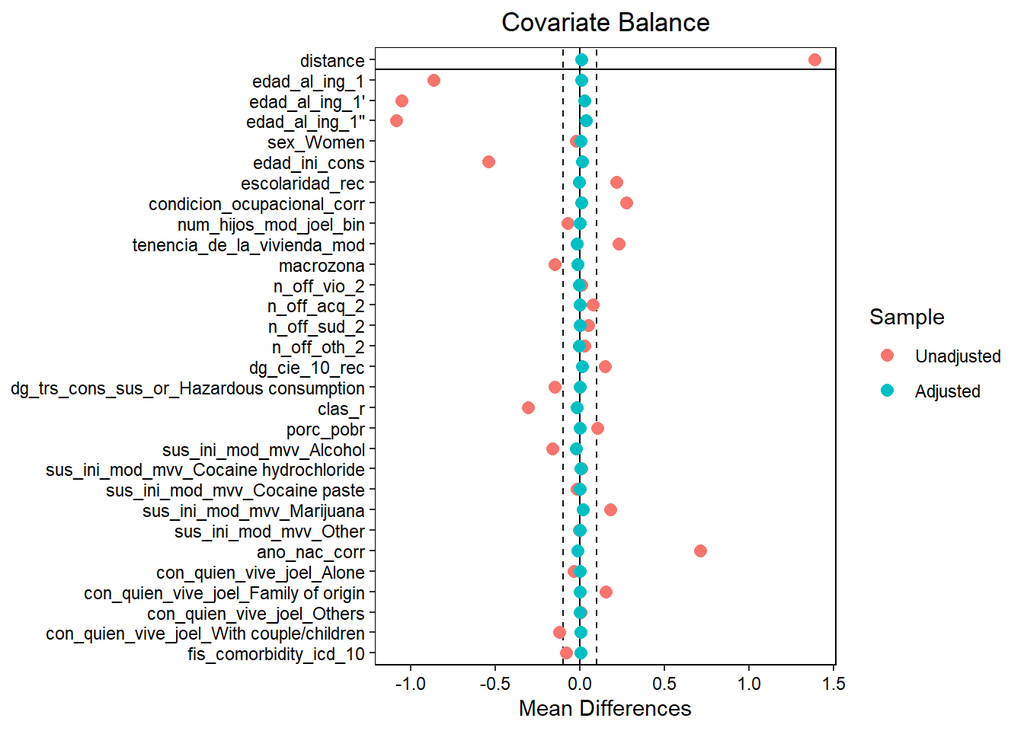

```r
plot(
cobalt::bal.tab(m.out3, un = TRUE, m.threshold = .1,
        v.threshold = 2))
```

```r
saveRDS(match.data(m.out3) %>%
  dplyr::select(edad_al_ing_1, policonsumo, edad_al_egres_imp, motivodeegreso_mod_imp_rec, age_offending_imp, offender_d, age_at_censor_date, subclass),
"base_senda_fiscalia.rds")
#%>%   rio::export("base_senda_fiscalia.tsv")
```

# Información de sesión

```r
message(paste0("Librería R: ", Sys.getenv("R_LIBS_USER")))
```

```
Librería R: H:/Mi unidad/PERSONAL ANDRES/UCH_salud_publica/asignaturas/9_Computacion_Estadistica/renv/library/R-4.1/x86_64-w64-mingw32;C:/Users/andre/AppData/Local/Temp/RtmpKaX4zN/renv-system-library
```

```r
message(paste0("Fecha: ",Sys.Date()))
```

```
Fecha: 2023-06-04
```

```r
message(paste0("Contexto editor: ", path))
```

```
Contexto editor: H:/Mi unidad/PERSONAL ANDRES/UCH_salud_publica/asignaturas/9_Computacion_Estadistica/env
```

```r
sesion_info <- devtools::session_info()
dplyr::select(
  tibble::as_tibble(sesion_info$packages),
  c(package, loadedversion, source)
) %>%
  DT::datatable(filter = 'top', colnames = c('Row number' =1,'Paquete' = 2, 'Versión'= 3),
              caption = htmltools::tags$caption(
        style = 'caption-side: top; text-align: left;',
        '', htmltools::em('Paquetes en R')),
      options=list(
initComplete = htmlwidgets::JS(
        "function(settings, json) {",
        "$(this.api().tables().body()).css({
            'font-family': 'Helvetica Neue',
            'font-size': '50%',
            'code-inline-font-size': '15%',
            'white-space': 'nowrap',
            'line-height': '0.75em',
            'min-height': '0.5em'
            });",#;
        "}")))
```

| Row number | Paquete | Versión | source |
| --- | --- | --- | --- |
| 1 | abind | 1.4-5 | CRAN (R 4.1.1) |
| 2 | admisc | 0.31 | CRAN (R 4.1.3) |
| 3 | askpass | 1.1 | CRAN (R 4.1.3) |
| 4 | backports | 1.4.1 | CRAN (R 4.1.2) |
| 5 | base64enc | 0.1-3 | CRAN (R 4.1.1) |
| 6 | broom | 1.0.4 | CRAN (R 4.1.3) |
| 7 | cachem | 1.0.7 | CRAN (R 4.1.3) |
| 8 | callr | 3.7.3 | CRAN (R 4.1.3) |
| 9 | car | 3.1-2 | CRAN (R 4.1.3) |
| 10 | carData | 3.0-5 | CRAN (R 4.1.3) |

[output cut: 177 more lines]

```r
 py_list_packages()%>%
  DT::datatable(filter = 'top', colnames = c('Row number' =1,'Paquete' = 2, 'Versión'= 3),
              caption = htmltools::tags$caption(
        style = 'caption-side: top; text-align: left;',
        '', htmltools::em('Paquetes en Python')),
      options=list(
initComplete = htmlwidgets::JS(
        "function(settings, json) {",
        "$(this.api().tables().body()).css({
            'font-family': 'Helvetica Neue',
            'font-size': '50%',
            'code-inline-font-size': '15%',
            'white-space': 'nowrap',
            'line-height': '0.75em',
            'min-height': '0.5em'
            });",#;
        "}")))
```

| Row number | Paquete | Versión | requirement |
| --- | --- | --- | --- |
| 1 | astor | 0.8.1 | astor==0.8.1 |
| 2 | astroid | 2.4.2 | astroid==2.4.2 |
| 3 | async-generator | 1.10 | async-generator==1.10 |
| 4 | attrs | 23.1.0 | attrs==23.1.0 |
| 5 | autograd | 1.5 | autograd==1.5 |
| 6 | autograd-gamma | 0.5.0 | autograd-gamma==0.5.0 |
| 7 | backcall | 0.2.0 | backcall==0.2.0 |
| 8 | beautifulsoup4 | 4.12.2 | beautifulsoup4==4.12.2 |
| 9 | behave | 1.2.6 | behave==1.2.6 |
| 10 | certifi | 2023.5.7 | certifi==2023.5.7 |

[output cut: 123 more lines]